# #Project Title:

Data Analysis & Forecasting to Improve Efficiency in a Food Manufacturing Company

🏭 Business Problem:

The food manufacturing company faced challenges including:

1. High scrap/waste in certain product lines.
2. Unbalanced production vs. demand, leading to overproduction and stockpiling.
3. Significant downtime during specific shifts, reducing overall plant efficiency.
4. Lack of demand forecasting, causing poor inventory planning.

   Project Objectives:

Identify operational inefficiencies across production units.

Analyze scrap rates and downtime patterns.

Recommend shift-level and product-level optimizations.

Build a predictive model to forecast future demand.

```python
# # 📦  Import Libraries
import pandas as pd
import matplotlib.pyplot as plt
import seaborn as sns

# Set styles
sns.set(style='whitegrid')
```

```python
from statsmodels.tsa.arima.model import ARIMA
import warnings
warnings.filterwarnings("ignore")
```

```python
df = pd.read_csv("C:/Users/Sushma Banu/Downloads/food_manufacturing_data.csv")
df['Date'] = pd.to_datetime(df['Date'])
```

```python
#Data Cleaning
df['Date'] = pd.to_datetime(df['Date'])          # Convert date
df.drop_duplicates(inplace=True)                 # Remove duplicates
df.isnull().sum()                                # Check missing values
```

```
Date                 0
Product              0
Batch_ID             0
Production_Unit      0
Quantity_Produced    0
Quantity_Scrapped    0
Downtime_Minutes     0
Employee_ID          0
Shift                0
Demand               0
dtype: int64
```

```python
#Feature Engineering
df['Scrap_Rate (%)'] = (df['Quantity_Scrapped'] / df['Quantity_Produced']) * 100
df['Production_Demand_Gap'] = df['Quantity_Produced'] - df['Demand']
df.head()
```

|  | Date | Product | Batch_ID | Production_Unit | Quantity_Produced | Quantity_Scrapped | Downtime_Minutes | Employee_ID | Shift | Demand | Scrap_Rate (%) | Production_Demand_Gap |
| --- | --- | --- | --- | --- | --- | --- | --- | --- | --- | --- | --- | --- |
| 0 | 2024-01-01 | Biscuits | B5641 | Unit_3 | 7270 | 416 | 19 | E565 | Morning | 6368 | 5.722146 | 902 |
| 1 | 2024-01-01 | Biscuits | B9447 | Unit_1 | 11896 | 569 | 60 | E186 | Evening | 12336 | 4.783120 | -440 |
| 2 | 2024-01-01 | Biscuits | B6225 | Unit_3 | 8795 | 480 | 59 | E877 | Evening | 8693 | 5.457646 | 102 |
| 3 | 2024-01-01 | Crackers | B2962 | Unit_1 | 11647 | 734 | 6 | E762 | Night | 11841 | 6.302052 | -194 |
| 4 | 2024-01-01 | Biscuits | B6341 | Unit_1 | 11405 | 634 | 17 | E562 | Night | 11700 | 5.558965 | -295 |

```python
# 📊 KPI Calculations

# 1. Scrap Rate by Product
scrap_by_product = df.groupby('Product')['Scrap_Rate (%)'].mean().sort_values(ascending=False)
print("Scrap Rate by Product:\n", scrap_by_product)

# 2. Downtime by Shift
downtime_by_shift = df.groupby('Shift')['Downtime_Minutes'].mean().sort_values(ascending=False)
print("\nDowntime by Shift:\n", downtime_by_shift)

# 3. Production-Demand Gap by Unit
gap_by_unit = df.groupby('Production_Unit')['Production_Demand_Gap'].mean().sort_values(ascending=False)
print("\nProduction-Demand Gap by Unit:\n", gap_by_unit)
```

```
Scrap Rate by Product:
 Product
Cookies     5.579043
Chips       4.903821
Namkeen     4.898775
Biscuits    4.696228
Crackers    4.616450
Name: Scrap_Rate (%), dtype: float64

Downtime by Shift:
 Shift
Evening    30.449612
Morning    29.437500
Night      29.032258
Name: Downtime_Minutes, dtype: float64

Production-Demand Gap by Unit:
 Production_Unit
Unit_3    279.227642
Unit_2    265.982301
Unit_1    226.534884
Name: Production_Demand_Gap, dtype: float64
```

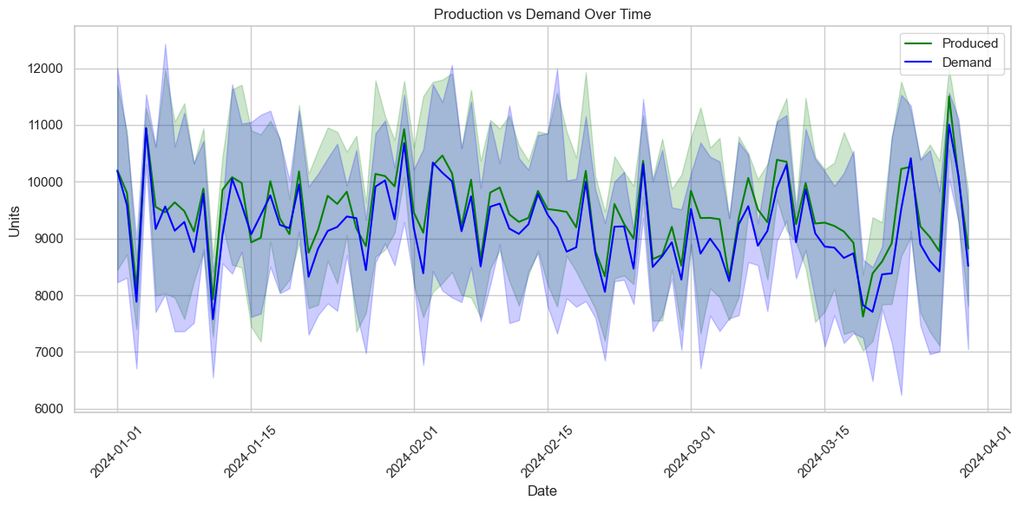

```python
# 📈 S Visualizations

# Line Plot: Production vs Demand
plt.figure(figsize=(12, 6))
sns.lineplot(data=df, x='Date', y='Quantity_Produced', label='Produced', color='green')
sns.lineplot(data=df, x='Date', y='Demand', label='Demand', color='blue')
plt.title('Production vs Demand Over Time')
plt.xticks(rotation=45)
plt.ylabel('Units')
plt.tight_layout()
plt.legend()
plt.show()
```

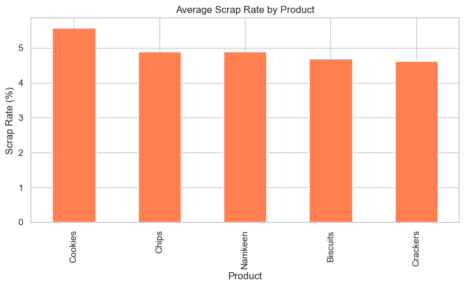

```python
# Bar Plot: Scrap Rate by Product
plt.figure(figsize=(8, 5))
scrap_by_product.plot(kind='bar', color='coral')
plt.title('Average Scrap Rate by Product')
plt.ylabel('Scrap Rate (%)')
plt.xlabel('Product')
plt.tight_layout()
plt.show()
```

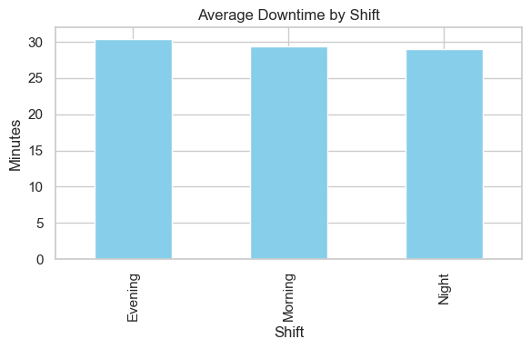

```python
# Bar Plot: Downtime by Shift
plt.figure(figsize=(6, 4))
downtime_by_shift.plot(kind='bar', color='skyblue')
plt.title('Average Downtime by Shift')
plt.ylabel('Minutes')
plt.xlabel('Shift')
plt.tight_layout()
plt.show()
```

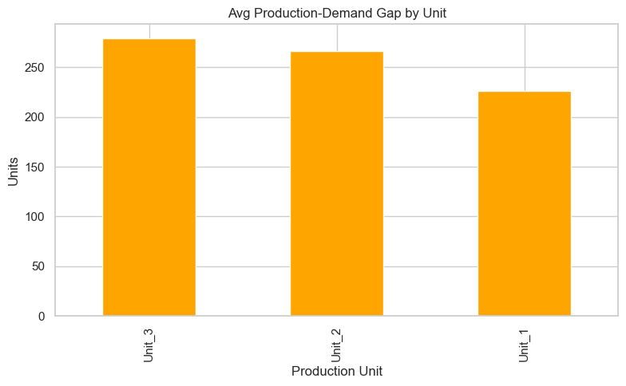

```python
# Bar Plot: Production-Demand Gap by Unit
plt.figure(figsize=(8, 5))
gap_by_unit.plot(kind='bar', color='orange')
plt.title('Avg Production-Demand Gap by Unit')
plt.ylabel('Units')
plt.xlabel('Production Unit')
plt.tight_layout()
plt.show()
```

# 📝 Business Insights

""" 🔍 Business Insights:

1. The product with the highest average scrap rate is: *Cookies*
2. The shift with the most average downtime is: *Evening*
3. The unit with the highest production-demand gap (overproduction) is: *Unit_3*
4. The unit with the lowest gap (closest to demand) is: *Unit_1*

## 📌 Recommendations:

- Investigate scrap issues with 'Cookies' line (possible machinery fault or training need).
- Improve scheduling or staffing for the 'Evening' shift to reduce downtime.
- Calibrate production targets for Unit_3 to avoid overproduction.

💡 Business Solutions & Recommendations:

1. Reduce Scrap in Cookies Line:

Conduct root-cause analysis on equipment and employee performance.

Use training, automation, or process refinement.

2. Optimize Evening Shift Efficiency:

Introduce mid-shift breaks or shift rotation.

Improve communication between shifts to reduce transition lag.

3. Control Overproduction in Unit_3:

Re-align production targets based on recent demand patterns.

Use the forecast model to set realistic quotas.

4. Implement Demand Forecasting System:

Use the ARIMA model (or Prophet, LSTM in future) to forecast weekly/monthly demand.

Update the model with new data regularly to enhance accuracy.

✅ Business Value Added:

Improved production planning based on demand forecasting.

Reduced operational waste and scrap losses.

Data-driven decision making for staffing and maintenance schedules.

Increased customer satisfaction by aligning production to demand.

### 📈 Prediction Goal: Forecast Future Product Demand

Why this helps the business:

Helps in planning production in advance

Reduces overproduction and underproduction

Optimizes inventory and reduces waste

```python
#🔹 Step 1: Import Libraries
from statsmodels.tsa.arima.model import ARIMA
import warnings
warnings.filterwarnings("ignore")
```

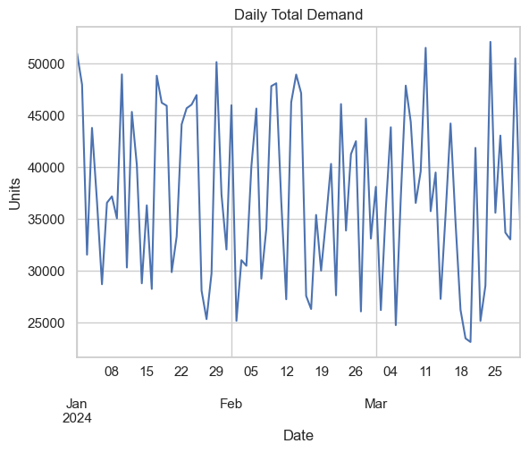

```python
#🔹 Step 2: Load and Prepare Data

df['Date'] = pd.to_datetime(df['Date'])

# Group total daily demand
demand_df = df.groupby('Date')['Demand'].sum().asfreq('D')  # daily frequency
demand_df = demand_df.fillna(method='ffill')  # fill any missing dates
demand_df.plot(title='Daily Total Demand')
plt.ylabel('Units')
plt.show()
```

```python
#🔹 Step 3: Build and Train ARIMA Model

# Fit ARIMA model: (p=5, d=1, q=2) – try different values as needed
model = ARIMA(demand_df, order=(5,1,2))
model_fit = model.fit()
print(model_fit.summary())
```

```
                               SARIMAX Results
==============================================================================
Dep. Variable:                 Demand   No. Observations:                   90
Model:                 ARIMA(5, 1, 2)   Log Likelihood                -925.013
Date:                Sat, 12 Jul 2025   AIC                           1866.025
Time:                        19:07:16   BIC                           1885.934
Sample:                    01-01-2024   HQIC                          1874.050
                         - 03-30-2024
Covariance Type:                  opg
==============================================================================
                 coef    std err          z      P>|z|      [0.025      0.975]
------------------------------------------------------------------------------
ar.L1         -0.4945      0.318     -1.553      0.120      -1.119       0.130
ar.L2         -0.1499      0.133     -1.125      0.261      -0.411       0.111
ar.L3         -0.0622      0.136     -0.457      0.648      -0.329       0.205
ar.L4         -0.1008      0.137     -0.734      0.463      -0.370       0.168
ar.L5          0.1406      0.136      1.037      0.300      -0.125       0.406
ma.L1         -0.4012      0.400     -1.004      0.315      -1.184       0.382
ma.L2         -0.5908      0.319     -1.850      0.064      -1.217       0.035
sigma2      6.598e+07   6.98e-09   9.46e+15      0.000     6.6e+07     6.6e+07
===================================================================================
Ljung-Box (L1) (Q):                   0.01   Jarque-Bera (JB):                 4.06
Prob(Q):                              0.91   Prob(JB):                         0.13
Heteroskedasticity (H):               0.98   Skew:                            -0.05
Prob(H) (two-sided):                  0.95   Kurtosis:                         1.96
===================================================================================

Warnings:
[1] Covariance matrix calculated using the outer product of gradients (complex-step).
[2] Covariance matrix is singular or near-singular, with condition number 2.28e+32. Standard errors may be unstable.
```

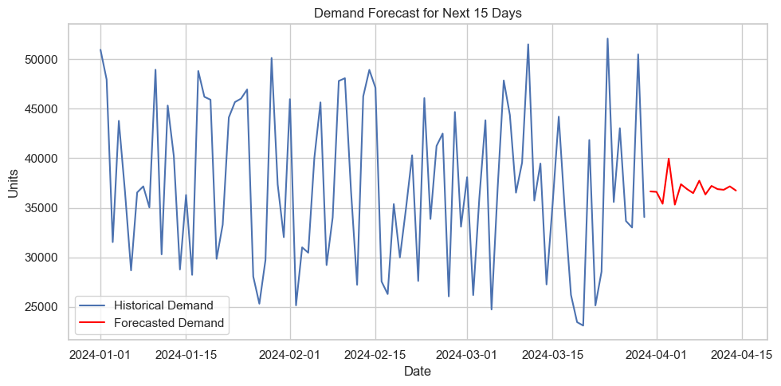

```python
#🔹 Step 4: Forecast Next 15 Days

forecast = model_fit.forecast(steps=15)
forecast.index = pd.date_range(demand_df.index[-1] + pd.Timedelta(days=1), periods=15)

# Plot forecast
plt.figure(figsize=(10, 5))
plt.plot(demand_df, label='Historical Demand')
plt.plot(forecast, label='Forecasted Demand', color='red')
plt.title('Demand Forecast for Next 15 Days')
plt.xlabel('Date')
plt.ylabel('Units')
plt.legend()
plt.tight_layout()
plt.show()
```

### 📊 Final Output:

A graph showing past demand and forecasted future demand

Use this forecast to optimize production and reduce scrap/waste